# Analyzing changes in soil organic matter during elevated CO₂ experiments

Chapter 4 Report Excercise – Data Wrangling

Ting Tan (22-108-534)

2025-06-08

## 1 Introduction

The $CO_2$ fertilization effect refers to the enhancement of plant growth resulting from elevated atmospheric carbon dioxide ($CO_2$) concentrations. As $CO_2$ is a fundamental substrate for photosynthesis, higher levels can stimulate photosynthetic rates in many plant species, leading to increased biomass production. This enhanced plant productivity can result in greater inputs of soil organic carbon ($SOC$) through leaf litter, root exudates, and other plant residues. However, increased carbon inputs may also stimulate microbial activity, potentially accelerating the decomposition of existing soil organic carbon—a process known as priming. Thus, while elevated $CO_2$ can initially promote carbon sequestration through increased plant growth, its long-term impact on soil carbon storage is complex and may be counteracted by faster microbial decomposition rates (Groenigen et al., 2014).

## 2 Research Question and Hypothesis

**How does the decomposition rate of soil organic carbon change response to the increased atmospheric $CO_2$ concentration?**

**Hypothesis**: Faster decomposition under increased atmospheric $CO_2$ limits soil carbon storage (Groenigen et al., 2014).

## 3 Available Data

This project uses *Database S1*, which was downloaded from the supplementary materials of the paper by Groenigen et al. (2014). *Database S1* contains data of soil organic carbon measurements in experiments, where ecosystems are exposed to ambient (low) and elevated (high) $CO_2$ concentrations (“$mean$”, $g C m_2$). The mean soil organic carbon of multiple samples (“$n$”, $g C m_2$) is recorded within each experiment for different sample dates. Information is provided for the time in years since the start of the experiment (“Time (years)”). We manually clean the data in the tab “Database S1” and save it as a CSV file that can be read into R in the the project data folder (`./data_raw/1249534s1.csv`)

## 4 Implementation

To evaluate the effect of elevated atmospheric CO₂ on soil organic carbon (SOC), we performed the following steps in R:

1. **Data Preparation:** Imported and cleaned the dataset, handled missing values, and renamed columns.
2. **Log-Response Ratio (LRR):** Calculated LRR for CO₂ concentration and SOC using `LRR = ln(x_elevated / x_ambient)` for each paired observation within experiments.
3. **Phase Classification:** Categorized observations into three temporal phases:
   - Early (<3 years), Mid (3–6 years), Late (>6 years).
4. **Aggregation:** Computed the mean LRR and standard error for each phase, based on individual LRRs rather than treatment means, to assess how CO₂ effects on SOC evolve over time.

## 5 Results and Discussion

From Table 1, we observe that the SOC response generally follows the same direction as changes in atmospheric CO₂ concentration. During the early phase of exposure, SOC increases at a faster rate than atmospheric CO₂, suggesting a strong initial accumulation of organic carbon in soil. However, this accumulation slows down in the mid phase and eventually reverses in the late phase, with SOC levels declining over time. This pattern—also illustrated in Figure 1—indicates that although elevated CO₂ may stimulate carbon input initially, it also promotes faster decomposition, which ultimately limits SOC accumulation.

Table 1: Summary of Log-Response Ratios by Phase

| Phase | CO₂ LRR (mean of phase) | SOC LRR (mean of phase) |
| --- | --- | --- |
| Early | 0.0125 | 0.0631 |
| Mid | 0.0172 | 0.0263 |
| Late | -0.0306 | -0.0061 |

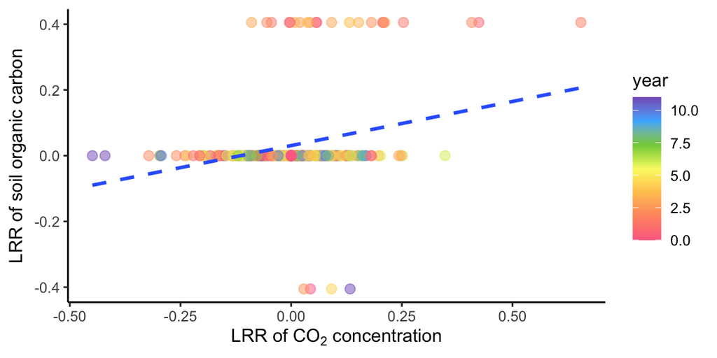

Figure 1: Scatterplot showing the relationship between the log-response ratio (LRR) of atmospheric CO₂ concentration and the LRR of soil organic carbon (SOC), including a linear regression trend line.

## Reference

Groenigen, K. J. van, Qi, X., Osenberg, C. W., Luo, Y., & Hungate, B. A. (2014). Faster decomposition under increased atmospheric CO$_2$ limits soil carbon storage. *Science*, *344*(6183), 508–509. https://doi.org/10.1126/science.1249534